# outline and central results - CAM in mediation

Julius Fenn, idea by Wilhelm Gros

30 11 2022

# 1 Outline

- additional to mean_valence of CAMs, we have multiple other (dependent) variables
  - multiple outcome variables (dummy, perceived acceptability)
  - multiple scales of the “Technology Acceptance Model”
  - PANAS Scale
  - general feelings about technology (livmats related questions)
  - multiple network indicators
- two general procedures of analysis are possible:
  - **quantitative:** test multiple models (multivariate multilevel models or mixed ANOVAs) regarding the mixed design
  - **qualitative:** summarize CAM data followed by *graph alignment* to check which specific areas of concepts (superordinate topics) have changed after the treatment
  - plus present usefullness of CAM method descriptively (e.g. aggregated CAM, discussion of general concerns)

# 2 Central Results

## 2.1 Descriptive

```r
## matching conditions (time X treatment)
table(dat_long$idcodegroup, dat_long$timepoint)
```

```
##
##             0  1
##   control  40 40
##   negative 17 17
##   positive 18 18
```

- just for illustration I include only 2 variables in the following analyses:

**mean_valence**

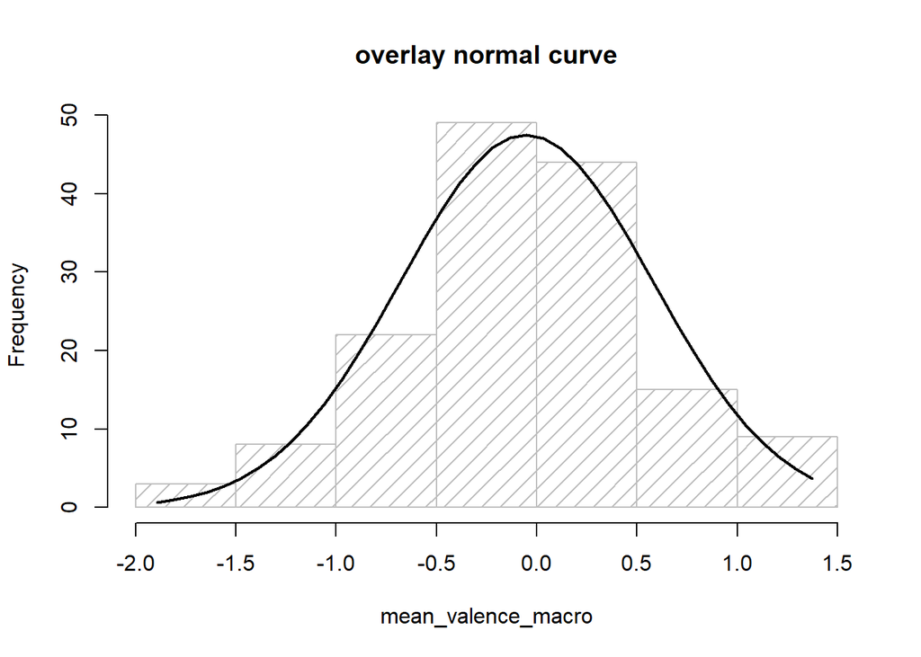

```r
g <- dat_long$mean_valence_macro
h <- hist(g, breaks = 10, density = 10,
          col = "gray", xlab = "mean_valence_macro", main = "overlay normal curve")
xfit <- seq(min(g), max(g), length = 40)
yfit <- dnorm(xfit, mean = mean(g), sd = sd(g))
yfit <- yfit * diff(h$mids[1:2]) * length(g)

lines(xfit, yfit, col = "black", lwd = 2)
```

**fc_panas_neg** which are computed factor scores of the negative emotion items of PANAS (using polychoric correlations to account for the non-normality of items, factor score computed using method Bartlett)

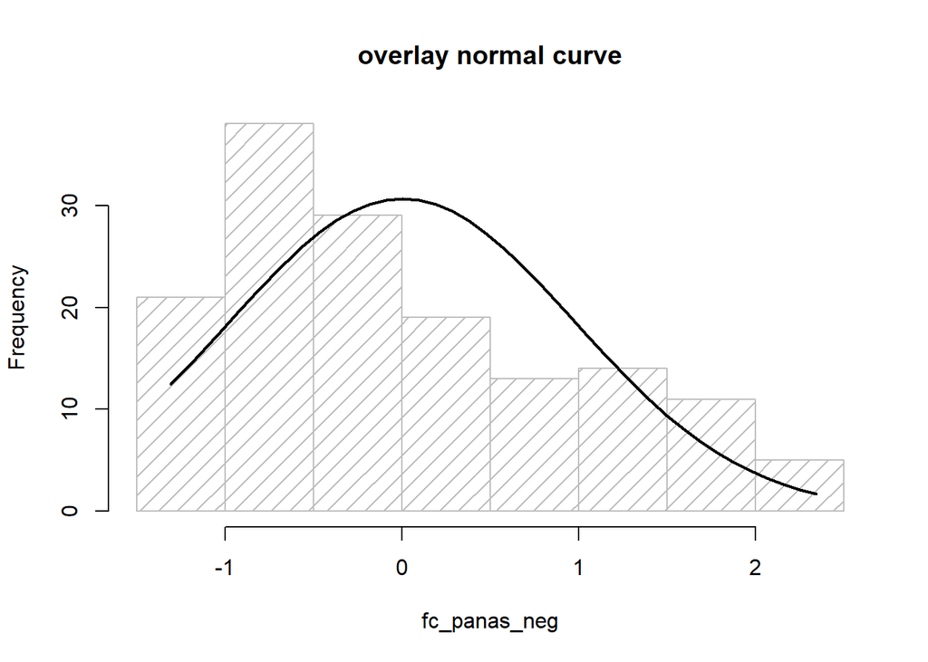

```r
g <- dat_long$fc_panas_neg
h <- hist(g, breaks = 10, density = 10,
          col = "gray", xlab = "fc_panas_neg", main = "overlay normal curve")
xfit <- seq(min(g), max(g), length = 40)
yfit <- dnorm(xfit, mean = mean(g), sd = sd(g))
yfit <- yfit * diff(h$mids[1:2]) * length(g)

lines(xfit, yfit, col = "black", lwd = 2)
```

## 2.2 multivariate multilevel models

*motivation using these kind of models: when computing ANOVAs in the context of regression models (= multivariate multilevel models) we do not need to run any post-hoc test anymore and in theory can compute more complex interactions of even latent regressions, for example, by applying so called latent change score models*

```r
# mean difference between fixed occasions model for 3 groups:
mmm1 <- lme(mean_valence_macro ~ 1 + post*idcodegroup_positive +
              post*idcodegroup_negative,
            random = ~ 1 + post | prolific_pid,
            data = dat_long,
            control=list(sigma=1e-10, opt="optim"))

summary(mmm1)
```

```
## Linear mixed-effects model fit by REML
##  Data: dat_long
##        AIC      BIC    logLik
##   797.0744 823.8027 -389.5372
##
## Random effects:
##  Formula: ~1 + post | prolific_pid
##  Structure: General positive-definite, Log-Cholesky parametrization
##             StdDev       Corr
## (Intercept) 0.5169812893 (Intr)
## post        0.5776007166 -0.308
## Residual    0.0000000001
##
## Fixed effects: mean_valence_macro ~ 1 + post * idcodegroup_positive + post *      idcodegroup_negative
##                                Value  Std.Error DF   t-value p-value
## (Intercept)               -0.1143336 0.08174192 72 -1.398715  0.1662
## post                       0.1908583 0.09132669 72  2.089841  0.0402
## idcodegroup_positive       0.4986140 0.14673124 72  3.398145  0.0011
## idcodegroup_negative      -0.4951828 0.14967794 72 -3.308322  0.0015
## post:idcodegroup_positive -0.7487482 0.16393643 72 -4.567308  0.0000
## post:idcodegroup_negative  0.4392326 0.16722865 72  2.626539  0.0105
##  Correlation:
##                           (Intr) post   idcdgrp_p idcdgrp_n pst:dcdgrp_p
## post                      -0.308
## idcodegroup_positive      -0.557  0.171
## idcodegroup_negative      -0.546  0.168  0.304
## post:idcodegroup_positive  0.171 -0.557 -0.308    -0.094
## post:idcodegroup_negative  0.168 -0.546 -0.094    -0.308     0.304
##
## Standardized Within-Group Residuals:
##           Min            Q1           Med            Q3           Max
## -4.440892e-06 -2.775558e-07  0.000000e+00  9.367507e-07  5.551115e-06
##
## Number of Observations: 150
## Number of Groups: 75
```

```r
# add Level-2 predictor fc_panas_neg
mmm2 <- lme(mean_valence_macro ~ 1 + post*idcodegroup_positive +
              post*idcodegroup_negative + post*fc_panas_neg,
            random = ~ 1 + post | prolific_pid,
            data = dat_long,
            control=list(sigma=1e-10, opt="optim"))

summary(mmm2)
```

```
## Linear mixed-effects model fit by REML
##  Data: dat_long
##      AIC      BIC   logLik
##   968.33 1000.844 -473.165
##
## Random effects:
##  Formula: ~1 + post | prolific_pid
##  Structure: General positive-definite, Log-Cholesky parametrization
##             StdDev       Corr
## (Intercept) 0.4993006469 (Intr)
## post        0.5703306675 -0.406
## Residual    0.0000000001
##
## Fixed effects: mean_valence_macro ~ 1 + post * idcodegroup_positive + post *      idcodegroup_negative + post * fc_panas_neg
##                                Value  Std.Error DF   t-value p-value
## (Intercept)               -0.1201878 0.07899702 72 -1.521422  0.1325
## post                       0.1493243 0.09090309 70  1.642676  0.1049
## idcodegroup_positive       0.5149217 0.14193195 72  3.627948  0.0005
## idcodegroup_negative      -0.4643226 0.14532596 72 -3.195043  0.0021
## fc_panas_neg              -0.1221259 0.05900800 70 -2.069650  0.0422
## post:idcodegroup_positive -0.7575414 0.16204641 70 -4.674842  0.0000
## post:idcodegroup_negative  0.5632036 0.16930477 70  3.326567  0.0014
## post:fc_panas_neg         -0.1313149 0.07221555 70 -1.818374  0.0733
##  Correlation:
##                           (Intr) post   idcdgrp_p idcdgrp_n fc_pn_ pst:dcdgrp_p
## post                      -0.402
## idcodegroup_positive      -0.558  0.223
## idcodegroup_negative      -0.547  0.217  0.308
## fc_panas_neg               0.036  0.011 -0.056    -0.103
## post:idcodegroup_positive  0.227 -0.553 -0.407    -0.127     0.045
## post:idcodegroup_negative  0.216 -0.556 -0.121    -0.395     0.014  0.300
## post:fc_panas_neg         -0.019  0.100  0.030     0.055    -0.533 -0.033
##                           pst:dcdgrp_n
## post
## idcodegroup_positive
## idcodegroup_negative
## fc_panas_neg
## post:idcodegroup_positive
## post:idcodegroup_negative
## post:fc_panas_neg         -0.194
##
## Standardized Within-Group Residuals:
##           Min            Q1           Med            Q3           Max
## -3.330669e-06 -5.551115e-07  0.000000e+00  1.110223e-06  3.330669e-06
##
## Number of Observations: 150
## Number of Groups: 75
```

**visualize results** for participants who had drawn a negative CAM and a positive prototype was presented

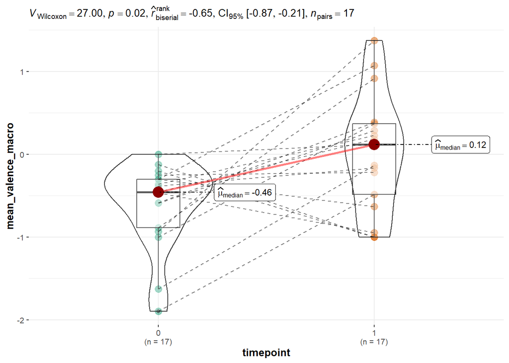

```r
# create a plot
p <- ggwithinstats(
  data = filter(dat_long, idcodegroup == "negative"),
  x    = timepoint,
  y    = mean_valence_macro,
  type = "np"
)
# looking at the plot
p
```

for participants who had drawn a positive CAM and a negative prototype was presented

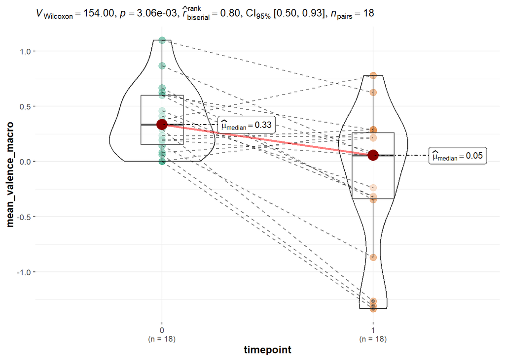

```r
# create a plot
p <- ggwithinstats(
  data = filter(dat_long, idcodegroup == "positive"),
  x    = timepoint,
  y    = mean_valence_macro,
  type = "np"
)
# looking at the plot
p
```

for participants where no prototype was presented

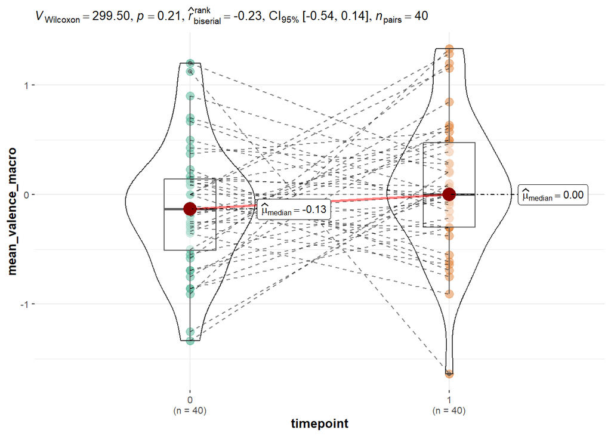

```r
# create a plot
p <- ggwithinstats(
  data = filter(dat_long, idcodegroup == "control"),
  x    = timepoint,
  y    = mean_valence_macro,
  type = "np"
)
# looking at the plot
p
```

## 2.3 mixed ANOVA

we get identical results to multivariate multilevel models, but also estimates for generalized and partial eta squared (effect sizes), which are nice to report if anyone in the future wants to do a meta-analysis on our results (recommendation of Daniel Lakens)

**mixed ANOVA**

```r
fit1 <- afex::aov_car(mean_valence_macro ~ timepoint*idcodegroup + Error(prolific_pid / timepoint),
                      data = dat_long)
```

```
## Converting to factor: idcodegroup
```

```
## Contrasts set to contr.sum for the following variables: idcodegroup
```

```r
fit1a <- afex::aov_ez(id = "prolific_pid", dv = "mean_valence_macro",
                      data = dat_long, between=c("idcodegroup"), within=c("timepoint"))
```

```
## Converting to factor: idcodegroup
## Contrasts set to contr.sum for the following variables: idcodegroup
```

```r
# partical eta squared
anova(fit1, es = "pes")
```

```
## Anova Table (Type 3 tests)
##
## Response: mean_valence_macro
##                       num Df den Df     MSE       F     pes    Pr(>F)
## idcodegroup                2     72 0.51754  2.8767 0.07400   0.06281 .
## timepoint                  1     72 0.16681  1.4882 0.02025   0.22648
## idcodegroup:timepoint      2     72 0.16681 19.3172 0.34921 1.923e-07 ***
## ---
## Signif. codes:  0 '***' 0.001 '**' 0.01 '*' 0.05 '.' 0.1 ' ' 1
```

```r
# generalized eta squared
fit1a # > identical results
```

```
## Anova Table (Type 3 tests)
##
## Response: mean_valence_macro
##                  Effect    df  MSE         F  ges p.value
## 1           idcodegroup 2, 72 0.52    2.88 + .057    .063
## 2             timepoint 1, 72 0.17      1.49 .005    .226
## 3 idcodegroup:timepoint 2, 72 0.17 19.32 *** .116   <.001
## ---
## Signif. codes:  0 '***' 0.001 '**' 0.01 '*' 0.05 '+' 0.1 ' ' 1
```

**visualize results**

```r
dfvalcor <- data_summary(dat_long, varname="mean_valence_macro",
                         groupnames=c("timepoint","idcodegroup"))
```

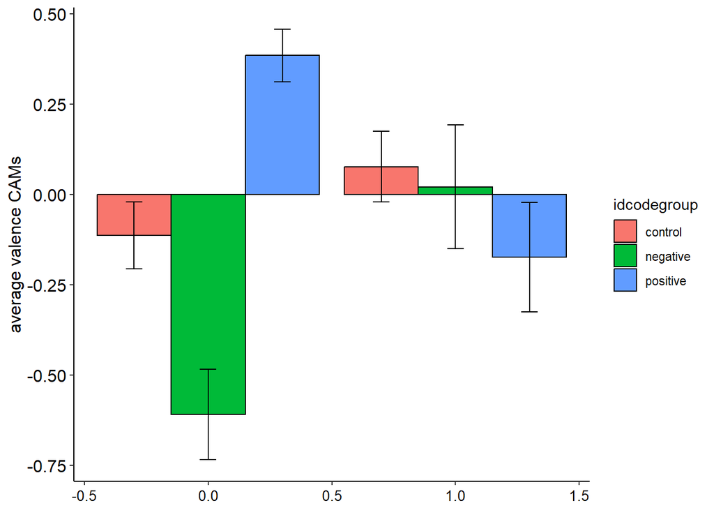

```r
p <- ggplot(dfvalcor, aes(x=timepoint, y=mean_valence_macro, fill=idcodegroup)) +
  geom_bar(stat="identity", color="black",
           position=position_dodge()) +
  geom_errorbar(aes(ymin=mean_valence_macro-se, ymax=mean_valence_macro+se), width=.2,
                position=position_dodge(.9)) + ggplot_theme + ylab(label = "average valence CAMs")
print(p)
```

**run post hoc tests**

```r
# Effect of group at each time point
one.way <- dat_long %>%
  group_by(timepoint) %>%
  anova_test(dv = mean_valence_macro, wid = prolific_pid, between = idcodegroup) %>%
  get_anova_table() %>%
  adjust_pvalue(method = "bonferroni")
```

```
## Coefficient covariances computed by hccm()
## Coefficient covariances computed by hccm()
```

```r
one.way
```

```
## # A tibble: 2 x 9
##   timepoint Effect        DFn   DFd      F          p `p<.05`   ges      p.adj
## *     <dbl> <chr>       <dbl> <dbl>  <dbl>      <dbl> <chr>   <dbl>      <dbl>
## 1         0 idcodegroup     2    72 16.2   0.00000159 "*"     0.31  0.00000318
## 2         1 idcodegroup     2    72  0.939 0.396      ""      0.025 0.792
```

```r
# Pairwise comparisons between group levels
pwc <- dat_long %>%
  group_by(timepoint) %>%
  pairwise_t_test(mean_valence_macro ~ idcodegroup, p.adjust.method = "bonferroni")
pwc
```

```
## # A tibble: 6 x 10
##   timepoint .y.               group1 group2    n1    n2       p p.signif   p.adj
## *     <dbl> <chr>             <chr>  <chr>  <int> <int>   <dbl> <chr>      <dbl>
## 1         0 mean_valence_mac~ contr~ negat~    40    17 1.47e-3 **       4.4 e-3
## 2         0 mean_valence_mac~ contr~ posit~    40    18 1.11e-3 **       3.33e-3
## 3         0 mean_valence_mac~ negat~ posit~    17    18 2.62e-7 ****     7.87e-7
## 4         1 mean_valence_mac~ contr~ negat~    40    17 7.66e-1 ns       1   e+0
## 5         1 mean_valence_mac~ contr~ posit~    40    18 1.77e-1 ns       5.3 e-1
## 6         1 mean_valence_mac~ negat~ posit~    17    18 3.77e-1 ns       1   e+0
## # ... with 1 more variable: p.adj.signif <chr>
```